# Ineens of gespreid instappen? — Belgische herijking (samenvattend rapport)

Auteur

Robbe De Win

Publicatiedatum

18 mei 2026

[figure not shown]

Persoonlijk financieel plan

18 mei 2026

Voor

# Ineens of gespreid instappen? — Belgische herijking (samenvattend rapport)

concept

Dit is het beknopte, *uitgerekende* rapport. De volledige prozabespreking staat in `chapters/01_framing.qmd`, `02_theorie.qmd` en `03_empirie_be.qmd`; de figuren worden gegenereerd door `notebooks/02_sensitivity.py`.

# De vraag

U heeft een windfall en een vast beleggingsdoel. Zet u het bedrag ineens voltallig in de markt, of gespreid over enkele maanden? De theorie (Constantinides 1979; Vanguard 2012/2023) zegt: ineens, want spreiden stelt het risico enkel uit en derft intussen de risicopremie. Dit rapport herijkt die conclusie op Belgische kosten (TOB-aankooptaks + vaste makelaarscommissie per order) en een lange reële rendementsgeschiedenis, en maakt expliciet *bij welke risicoaversie* gespreid instappen toch verdedigbaar wordt.

# Hoofdresultaat (live berekend)

**Casus:** Erfenis rechte lijn ≈ € 150 000 — de meest voorkomende casus. Horizon 10 jaar 100 % aandelen DCA over 12 maanden centrale kalibratie.

- Gemiddeld reëel eindvermogen lump-sum: € 326 060

- Gemiddeld reëel eindvermogen DCA: € 314 101

- Voorsprong lump-sum: **3.7%** (DCA wint in 32% van de paden)

- Extra DCA-kost (vaste commissie + TOB): € 83

- DCA verlaagt de verwachte maximale terugval met 0.94 pp

**Verdict:** Lump-sum verslaat DCA gemiddeld met € 11 959 (3.7%) — tijd in de markt wint. DCA verlaagt wel de verwachte maximale terugval met 0.9 pp; dat is de prijs van gemoedsrust niet van rendement.

# Eindvermogen en zekerheidsequivalent per casus

| Casus | Bedrag (€) | γ | Gem. lump (€) | Gem. DCA (€) | CE lump (€) | CE DCA (€) | CE kiest DCA |
| --- | --- | --- | --- | --- | --- | --- | --- |
| bonus | 25 000 | 2 | 54 636 | 52 533 | 41 181 | 40 385 | nee |
| bonus | 25 000 | 4 | 54 636 | 52 533 | 29 516 | 29 613 | ja |
| bonus | 25 000 | 8 | 54 636 | 52 533 | 15 189 | 15 542 | ja |
| inheritance | 150 000 | 2 | 327 901 | 316 149 | 247 150 | 243 043 | nee |
| inheritance | 150 000 | 4 | 327 901 | 316 149 | 177 138 | 178 215 | ja |
| inheritance | 150 000 | 8 | 327 901 | 316 149 | 91 158 | 93 530 | ja |
| property_rollover | 400 000 | 2 | 874 430 | 843 382 | 659 089 | 648 358 | nee |
| property_rollover | 400 000 | 4 | 874 430 | 843 382 | 472 383 | 475 418 | ja |
| property_rollover | 400 000 | 8 | 874 430 | 843 382 | 243 096 | 249 508 | ja |

*Lezing:* bij lage risicoaversie wint ineens-instappen op élke maat; naarmate γ stijgt keert het zekerheidsequivalent om en wordt gespreid instappen een verdedigbare preferentiekeuze — geen rendementsoptimalisatie.

# Break-even risicoaversie

- **100 % aandelen, horizon 15 jr:** geen kruising in γ ∈ [0,5; 30] — ineens-instappen wint zelfs voor de zeer risicoschuwe belegger.

# Figuren

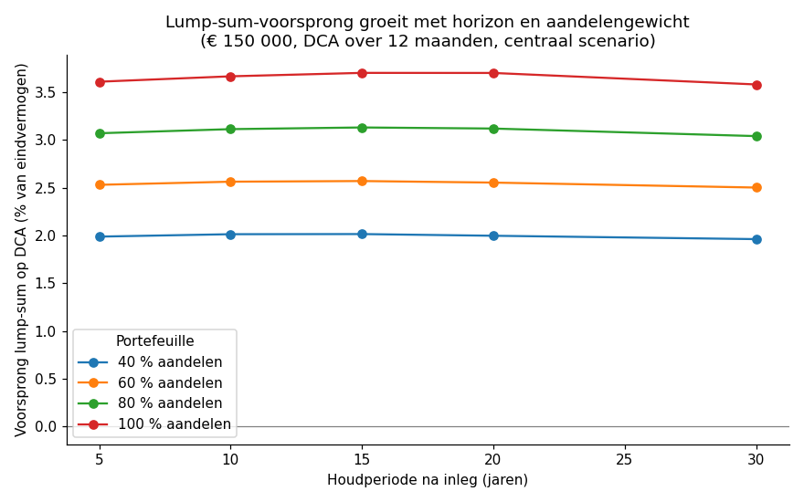

Voorsprong lump-sum vs horizon en aandelengewicht

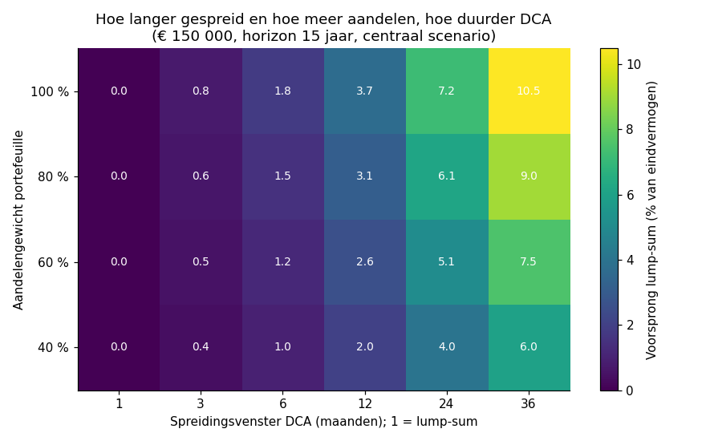

Voorsprong over spreidingsvenster × aandelengewicht

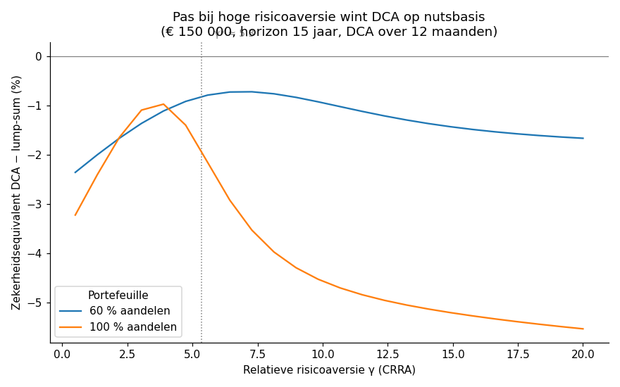

Zekerheidsequivalent DCA − lump-sum vs risicoaversie

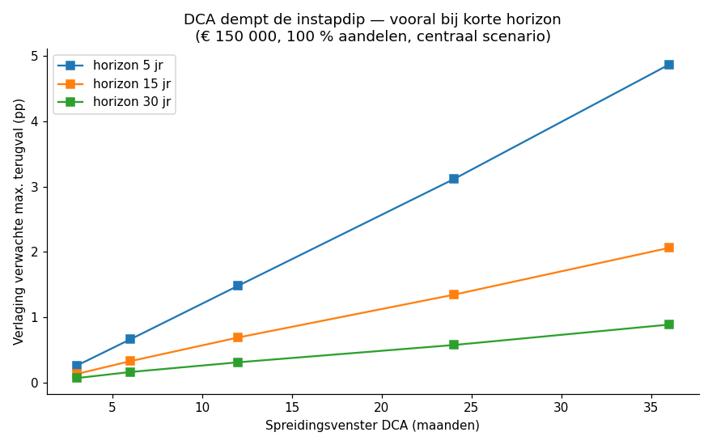

Demping van de maximale terugval

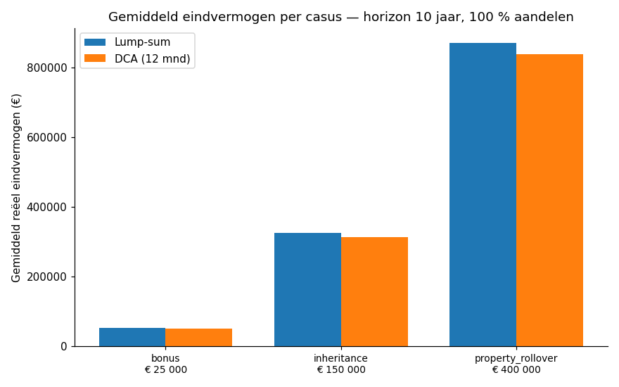

Gemiddeld eindvermogen per casus

# Besluit

Ineens-instappen wint gemiddeld, ook na Belgische kosten en in reële termen; de kloof is enkele procenten en gedraagt zich zoals de theorie voorspelt. De vaste commissie is niet de hoofdkost — de opportuniteitskost van het wachtende geld is dat. Gespreid instappen blijft verdedigbaar als *spijtverzekering* voor de voldoende risicoschuwe belegger, bij voorkeur met een kort venster. De volledige onderbouwing staat in de hoofdstukken; de herbruikbare motor is `shared.projections.dca_vs_lumpsum`.